# iRep

```r
library(tidyverse)
library(dplyr)
library(readr)
library(vegan)
library(lme4)
library(lmerTest)
library(rstatix)
library(ggridges)
library(patchwork)
library(readxl)
```

Summarize the MAG list of interest to create a .csv file with various sam - mag pairs for irep runs.

```
## # A tibble: 3 × 2
##   date    unique_mags
##   <chr>         <int>
## 1 7/19/19          22
## 2 8/13/19          28
## 3 9/18/19          28
```

```
## [1] 21
```

```
## [1] 6
```

```
## [1] 3
```

There are over 20 MAGs in each date (22, 28, and 28). Out of 30 MAGs being considered here, 21 appear in all three, 6 in two, and 3 in one date.

Load irep results.

```
## [1] 30
```

```
## [1] 22
```

```
## [1] 574
```

This matches what we would expect. We have 30 MAGs (15 resistant, 15 randomly picked susceptible), 22 assemblies, and 574 irep runs.

Compare median between two categories for randomly selected MAGs

```
## Resistant MAGs irep values - Mean: 2.879271 , Median: 2.734915 , Stdev: 0.8154965 , Range: 1.471945 6.087612
```

```
## Susceptible MAGs irep values - Mean: 2.646382 , Median: 2.475271 , Stdev: 0.9205703 , Range: 1.397626 8.326328
```

Basic non-parametric stats

```
##
##  Wilcoxon rank sum test with continuity correction
##
## data:  res_irep_results and sus_irep_results
## W = 48717, p-value = 3.321e-05
## alternative hypothesis: true location shift is not equal to 0
```

p-value is extremely small (0.00003321), indicating that (counter to hypothesis, if anything) resistant populations have a higher median growth rate.

Use mixed effects models since intrinsic variation in growth rates (at the mag level, due to date etc.) potentially introduces variation.

Below, random effect is grouped by MAG. This avoids introducing bias in the fixed effect estimates by accounting for intrinsic variability at the individual MAG level.

```
## Linear mixed model fit by REML. t-tests use Satterthwaite's method [
## lmerModLmerTest]
## Formula: irep_unfiltered ~ response_category + (1 | mag)
##    Data: irep_results
##
## REML criterion at convergence: 1259.4
##
## Scaled residuals:
##     Min      1Q  Median      3Q     Max
## -2.1346 -0.5804 -0.1714  0.4696  7.3967
##
## Random effects:
##  Groups   Name        Variance Std.Dev.
##  mag      (Intercept) 0.2999   0.5477
##  Residual             0.4578   0.6766
## Number of obs: 574, groups:  mag, 30
##
## Fixed effects:
##                              Estimate Std. Error      df t value Pr(>|t|)
## (Intercept)                    2.8805     0.1464 27.2952  19.679   <2e-16 ***
## response_categorysusceptible  -0.2447     0.2087 28.1193  -1.173    0.251
## ---
## Signif. codes:  0 '***' 0.001 '**' 0.01 '*' 0.05 '.' 0.1 ' ' 1
##
## Correlation of Fixed Effects:
##             (Intr)
## rspns_ctgry -0.702
```

Results:

Fixed Effects: - Intercept (Estimate = 2.8805). This represents the baseline reference (in this case, baseline irep value is for the resistant populations). So an average resistant MAG has an irep value of 2.88 in our data. - response_categorysusceptible (Estimate = -0.2447) represents Δ irep (susceptible - resistant MAGs). Thus, on average, susceptible MAGs have a 0.2447 irep unit lower than resistant MAGs. However, this effect is not significant (p = 0.251), suggesting no strong evidence for the difference in instantaneous growth rates between resistant and susceptible populations in this model - Residual variance (0.4578) represents the variability that remains unexplained by the model.

Random effects: - Variance = 0.2999 and Std.Dev. = 0.5477. This indicates that there is quite a lot variability in the irep values among unique MAGs.

Biological interpretation: - The hypothesis of a growth-defense trade-off suggests that resistant populations should grow slower due to growth-defense trade-offs. However, we see an opposite trend here, where susceptible MAGs grow slightly slower (-0.2447). However, the lack of statistical significance (0.251) and large standard error (0.2087) indicate that a different model might fit better. Results from this model imply that - a) growth-defense trade-offs may not strongly structure growth traits in this system b) environmental or experimental factors may mitigate or relax the trade-offs constraints. c) resistant MAGs have evolved mechanisms that minimize growth penalties while maintaining grazing resistance.

Next, 1) Visualize residuals against date and treatment to identify patterns of heterogeneity. Temporal trends (Residuals vs. Date) or difference between categories (Residuals vs. Treatment) will suggest the need to include date and/or treatment to the model. 2) Check for any potential interactions between variables.

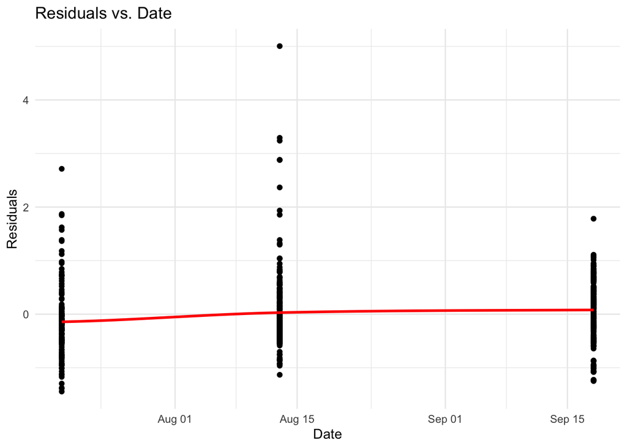

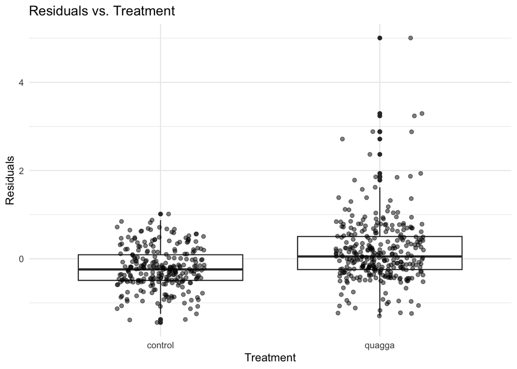

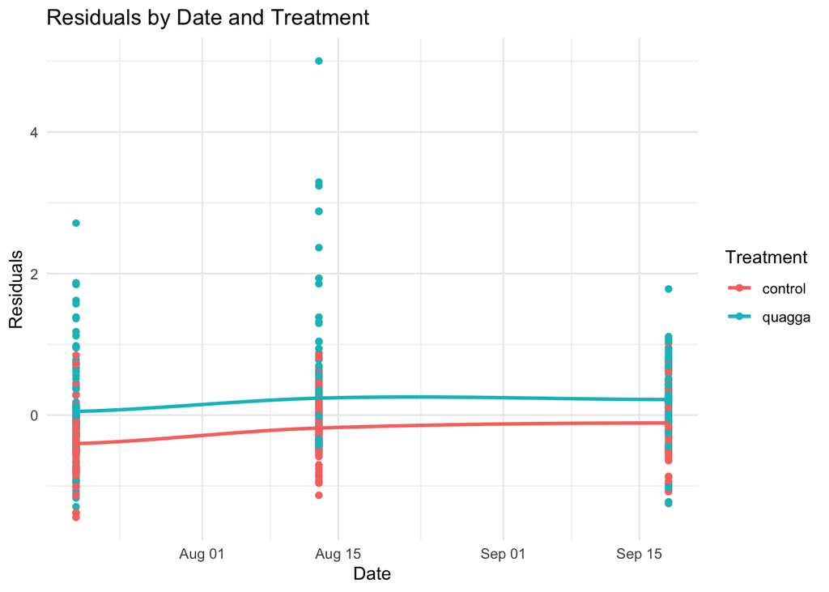

- Residuals increase over time for date, suggesting temporal variability in irep values not captured by the initial model. We will add date in the model (add as a fixed effect for linear trends or as a random effect for batch effects).  
- Residuals for quagga are higher than control, implying that the mussel treatment may be influencing irep values. - Both control and quagga following similar trends over time indicates that the effect of treatment (on irep values) does not vary with date. Therefore, an interaction term between treatment and date is not necessary. However, the inclusion of both date and treatment in the model is still warranted to capture their influence on irep values.

- Now check potential interaction between response category and treatment. Basically, are the irep values of the populations in different response_category groups (resistant vs susceptible) being affected differently by the mussel treatment? If irep values are capturing how populations in these categories respond to feeding, the difference in their response may suggest plasticity of adjusting growth rate as an ecological strategy.

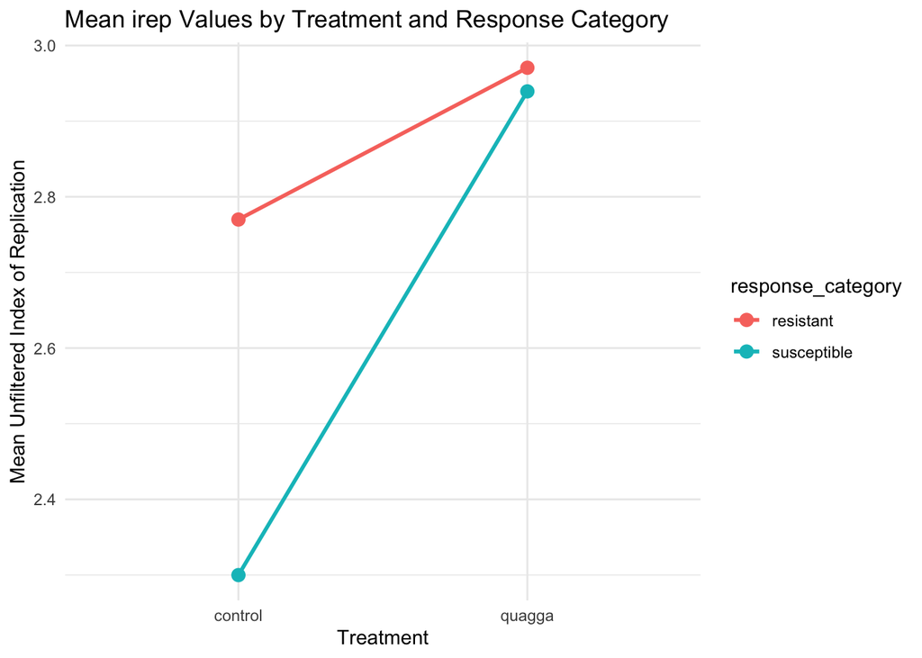

```
##   treatment response_category irep_unfiltered
## 1   control         resistant        2.769935
## 2    quagga         resistant        2.970592
## 3   control       susceptible        2.299913
## 4    quagga       susceptible        2.939352
```

The shift in mean irep value, in response to quagga treatment is 0.2 for resistant and 0.64 for susceptible populations. This implies that an interaction term between response category and treatment should be included in the model.

Explore the date effect a bit further to see whether to makes sense to add it as fixed effect or random effect.

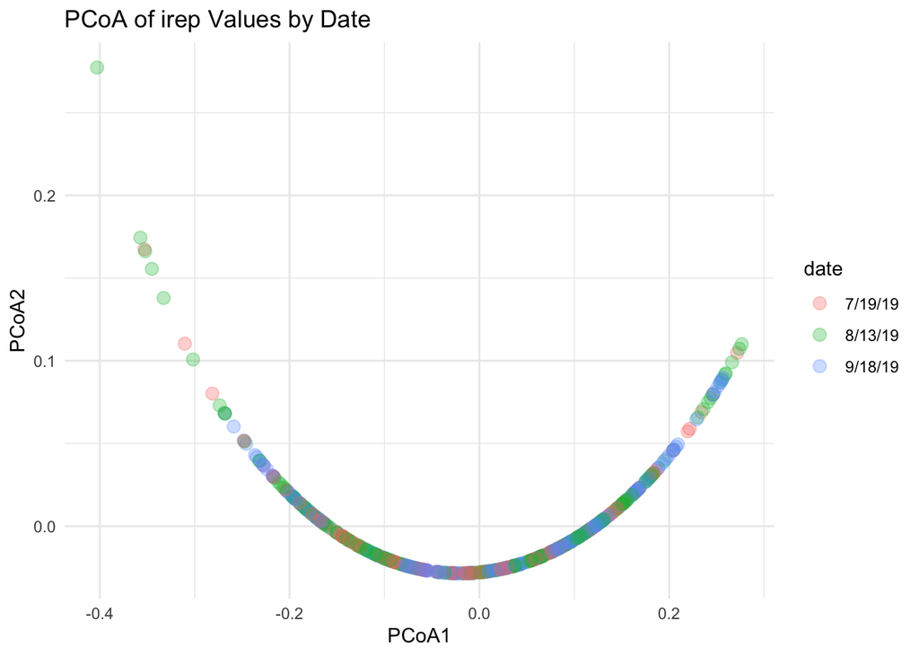

**Statistical models**

```
## refitting model(s) with ML (instead of REML)
```

```
## Data: irep_results
## Models:
## model_m1: irep_unfiltered ~ response_category + treatment + (1 | mag)
## model_m2: irep_unfiltered ~ response_category * treatment + date + (1 + treatment | mag)
## model_m3: irep_unfiltered ~ response_category * treatment + date + (1 + treatment + date | mag)
##          npar     AIC    BIC  logLik deviance   Chisq Df Pr(>Chisq)
## model_m1    5 1214.66 1236.4 -602.33  1204.66
## model_m2   10 1181.95 1225.5 -580.98  1161.95  42.703  5  4.244e-08 ***
## model_m3   17  928.56 1002.5 -447.28   894.56 267.393  7  < 2.2e-16 ***
## ---
## Signif. codes:  0 '***' 0.001 '**' 0.01 '*' 0.05 '.' 0.1 ' ' 1
```

General idea here: - fixed effects are for variation across mags i.e. across all irep values in the df - random effects are for variation within mags, based on the ways the models are parameterized

First model one and 2 were run. Rationale for going to m3 from m2 is that residual variance is almost 54% (based on proportion) for m2 and treatment accounts for 10%. When we go to m3, the residual is only 10%, and date accounts for 38% and 29% (for 2 dates), suggesting that temporal dynamics/heterogeneity is important in driving the irep values withtin mags. Note: make summary table for intecepts, what that represents, and p-values.

```
## Linear mixed model fit by REML. t-tests use Satterthwaite's method [
## lmerModLmerTest]
## Formula: irep_unfiltered ~ response_category + treatment + (1 | mag)
##    Data: irep_results
##
## REML criterion at convergence: 1212.7
##
## Scaled residuals:
##     Min      1Q  Median      3Q     Max
## -2.2883 -0.5606 -0.0967  0.4931  7.4587
##
## Random effects:
##  Groups   Name        Variance Std.Dev.
##  mag      (Intercept) 0.3030   0.5505
##  Residual             0.4177   0.6463
## Number of obs: 574, groups:  mag, 30
##
## Fixed effects:
##                               Estimate Std. Error        df t value Pr(>|t|)
## (Intercept)                    2.66561    0.14959  29.58832  17.819  < 2e-16
## response_categorysusceptible  -0.24374    0.20891  28.09049  -1.167    0.253
## treatmentquagga                0.39455    0.05417 543.16442   7.284 1.15e-12
##
## (Intercept)                  ***
## response_categorysusceptible
## treatmentquagga              ***
## ---
## Signif. codes:  0 '***' 0.001 '**' 0.01 '*' 0.05 '.' 0.1 ' ' 1
##
## Correlation of Fixed Effects:
##             (Intr) rspns_
## rspns_ctgry -0.688
## treatmntqgg -0.197  0.001
```

```
## Linear mixed model fit by REML. t-tests use Satterthwaite's method [
## lmerModLmerTest]
## Formula: irep_unfiltered ~ response_category * treatment + date + (1 +
##     treatment | mag)
##    Data: irep_results
##
## REML criterion at convergence: 1179.5
##
## Scaled residuals:
##     Min      1Q  Median      3Q     Max
## -2.6107 -0.5638 -0.0689  0.4079  7.2768
##
## Random effects:
##  Groups   Name            Variance Std.Dev. Corr
##  mag      (Intercept)     0.21855  0.4675
##           treatmentquagga 0.07437  0.2727   0.53
##  Residual                 0.37943  0.6160
## Number of obs: 574, groups:  mag, 30
##
## Fixed effects:
##                                               Estimate Std. Error        df
## (Intercept)                                    2.61059    0.13798  33.14227
## response_categorysusceptible                  -0.50835    0.18791  28.40884
## treatmentquagga                                0.20583    0.09860  21.66736
## date8/13/19                                    0.20918    0.06652 514.85758
## date9/18/19                                    0.24196    0.06915 517.55707
## response_categorysusceptible:treatmentquagga   0.44640    0.14491  24.30161
##                                              t value Pr(>|t|)
## (Intercept)                                   18.919  < 2e-16 ***
## response_categorysusceptible                  -2.705 0.011410 *
## treatmentquagga                                2.088 0.048808 *
## date8/13/19                                    3.145 0.001759 **
## date9/18/19                                    3.499 0.000507 ***
## response_categorysusceptible:treatmentquagga   3.081 0.005074 **
## ---
## Signif. codes:  0 '***' 0.001 '**' 0.01 '*' 0.05 '.' 0.1 ' ' 1
##
## Correlation of Fixed Effects:
##             (Intr) rspns_ trtmnt d8/13/ d9/18/
## rspns_ctgry -0.651
## treatmntqgg  0.135 -0.104
## date8/13/19 -0.288 -0.028  0.030
## date9/18/19 -0.270 -0.032  0.001  0.582
## rspns_ctgr: -0.094  0.113 -0.680 -0.005 -0.007
```

```
## Linear mixed model fit by REML. t-tests use Satterthwaite's method [
## lmerModLmerTest]
## Formula: irep_unfiltered ~ response_category * treatment + date + (1 +
##     treatment + date | mag)
##    Data: irep_results
##
## REML criterion at convergence: 908.8
##
## Scaled residuals:
##     Min      1Q  Median      3Q     Max
## -2.8191 -0.3514 -0.0500  0.2185  8.2487
##
## Random effects:
##  Groups   Name            Variance Std.Dev. Corr
##  mag      (Intercept)     0.2596   0.5095
##           treatmentquagga 0.1403   0.3746    0.14
##           date8/13/19     0.5221   0.7226   -0.38  0.26
##           date9/18/19     0.6852   0.8278   -0.56 -0.15  0.52
##  Residual                 0.1782   0.4222
## Number of obs: 574, groups:  mag, 30
##
## Fixed effects:
##                                              Estimate Std. Error      df
## (Intercept)                                    2.6796     0.1338 25.1920
## response_categorysusceptible                  -0.5650     0.1780 29.0650
## treatmentquagga                                0.2262     0.1044 24.7607
## date8/13/19                                    0.1622     0.1516 26.6877
## date9/18/19                                    0.1663     0.1706 22.8411
## response_categorysusceptible:treatmentquagga   0.4259     0.1458 24.0492
##                                              t value Pr(>|t|)
## (Intercept)                                   20.032  < 2e-16 ***
## response_categorysusceptible                  -3.174  0.00354 **
## treatmentquagga                                2.165  0.04019 *
## date8/13/19                                    1.070  0.29434
## date9/18/19                                    0.975  0.33998
## response_categorysusceptible:treatmentquagga   2.922  0.00745 **
## ---
## Signif. codes:  0 '***' 0.001 '**' 0.01 '*' 0.05 '.' 0.1 ' ' 1
##
## Correlation of Fixed Effects:
##             (Intr) rspns_ trtmnt d8/13/ d9/18/
## rspns_ctgry -0.516
## treatmntqgg  0.026 -0.021
## date8/13/19 -0.364 -0.108  0.170
## date9/18/19 -0.480 -0.092 -0.089  0.560
## rspns_ctgr: -0.006  0.018 -0.669 -0.028 -0.002
```

**Random effects summary for 3 models:**

Model 1: mag (Intercept) 0.3030 0.5505  
Residual 0.4177 0.6463

Model 2: mag (Intercept) 0.21855 0.4675  
treatmentquagga 0.07437 0.2727  
Residual 0.37943 0.6160

Model 3: mag (Intercept) 0.2596 0.5095  
treatmentquagga 0.1403 0.3746  
date8/13/19 0.5221 0.7226  
date9/18/19 0.6852 0.8278  
Residual 0.1782 0.4222

We can compute Intraclass Correlation Coefficient (ICC), which will give us the proportion of total variance explained by random effects.(Sum of Random Effects Variances/Total Variance): - Model 1: Random effects (MAG = 0.303); residual = 0.418 i.e. Total proportion explained = (0.303) / (0.303+0.418) = 0.303/0.721 = 0.42 or ~42%

We can calculate the residual variance reduction of Model 3: 1 - residualVariance (model 3)/ residualVariance (model1 or 2) - Model 3 vs. Model 1: (1 - (0.1782/0.4177)) = 0.57; Thus, 57% reduction in variance in model 3 compared to model 1 - Model 3 vs. Model 2: (1 - (0.1782/0.3794)) = 0.53; Thus, 52% reduction in variance in model 3 compared to model 2

For models 2 and 3, test performance. Randomly split data into 80% training and 20% testing parts, and evaluate model performance using MSE and R2.

```
## Model 2: MSE = 0.4490309 , R² = 0.4183728
```

```
## Model 3: MSE = 0.237416 , R² = 0.6924764
```

Repeat performance tests with different proportions of training and test data.

```
##    Train_Proportion Model       MSE        R2
## 1               0.8    m2 0.4490309 0.4183728
## 2               0.8    m3 0.2374160 0.6924764
## 3               0.7    m2 0.5174493 0.4437163
## 4               0.7    m3 0.2928902 0.6851285
## 5               0.6    m2 0.5823120 0.3667288
## 6               0.6    m3 0.3078194 0.6652428
## 7               0.5    m2 0.3870922 0.4434345
## 8               0.5    m3 0.2315512 0.6670731
## 9               0.4    m2 0.4722644 0.3802028
## 10              0.4    m3 0.2929175 0.6155766
```

Figure 4A: Joy divison plot to visualize variance in irep values across mags.

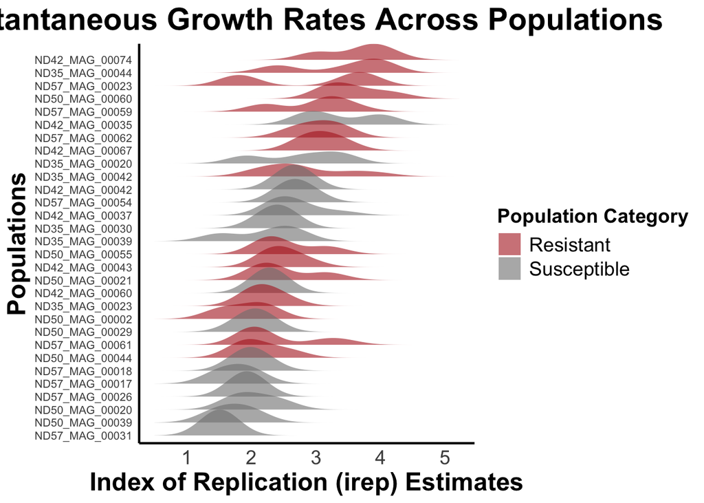

Figure 4A:Visualize statistical findings of irep values.

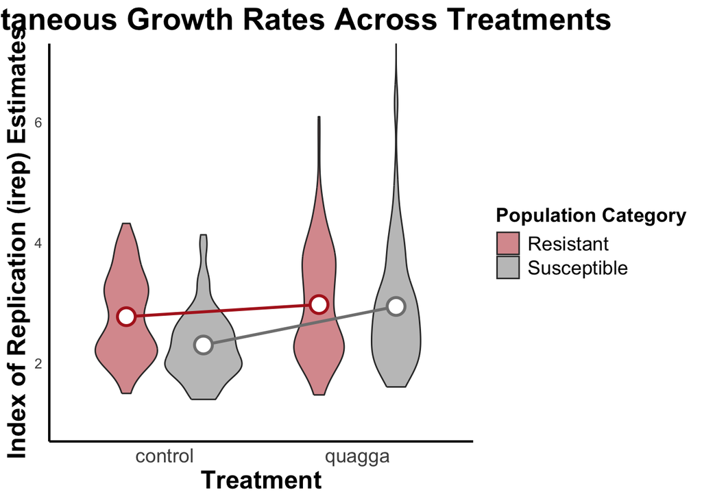